# 🕸️ Advanced Web Scraping Project – IBM Data Analyst Capstone

This project explores deeper web scraping skills:

- Scraping programming language popularity data
- Parsing structured HTML tables
- Cleaning, analyzing, and saving scraped data
- Visualizing top programming languages

# 🕸️ **Case Study: Web Scraping Project**

# Objectives

After completing this hands-on lab work, we will be able to:

- Extract information from a given web site.
- Write the scraped data into a csv file.

## Extract information from the given web site

You will extract the data from the below web site:

```python
#this url contains the data you need to scrape
url = "https://cf-courses-data.s3.us.cloud-object-storage.appdomain.cloud/IBM-DA0321EN-SkillsNetwork/labs/datasets/Programming_Languages.html"
```

The data you need to scrape is the **name of the programming language** and **average annual salary**.  
It is a good idea to open the url in your web broswer and study the contents of the web page before you start to scrape.

Import the required libraries

```python
from bs4 import BeautifulSoup # this module helps in web scrapping.
import requests  # this module helps us to download a webpage
import pandas as pd
```

Download the webpage at the url

```python
!pip install openpyxl
```

```python
# get the contents of the webpage in text format and store in a variable called data
data  = requests.get(url)
data = data.text
```

Create a soup object

```python
soup = BeautifulSoup(data,"html.parser")  # create a soup object using the variable 'data'
```

Scrape the `Language name` and `annual average salary`.

```python
for link in soup.find_all('a'): # in html anchor/link is represented by the tag <a>
    print(link.get('href'))
```

```python
#find a html table in the web page
table = soup.find('table') # in html table is represented by the tag <table>
```

```python
# Extract column headers (Handle cases where headers are missing `<th>`)
headers = []
header_row = table.find("tr")  # Find the first row (headers may be inside <td>)
if header_row:
    headers = [header.text.strip() for header in header_row.find_all(["th", "td"])]  # Search for both <th> and <td>

# Extract table rows
rows = []
for row in table.find_all("tr")[1:]:  # Skip header row
    cols = row.find_all("td")
    cols = [col.text.strip() for col in cols]
    rows.append(cols)

# Ensure headers exist, otherwise create default headers
if not headers:
    headers = [f"Column_{i}" for i in range(len(rows[0]))]  # Create generic column names if none found

# Convert to a pandas DataFrame
df_languages = pd.DataFrame(rows, columns=headers)
```

Save the scrapped data into a file named *popular-languages.csv*

```python
# Save the scraped data into a CSV file
csv_filename = "popular-languages.csv"
df_languages.to_csv(csv_filename, index=False)

# Display the extracted data
print(f"Popular Programming Languages {df_languages}.")

print(f"Scraped data successfully saved in {csv_filename}.")
```

```
Popular Programming Languages   No.    Language                                 Created By  \
0   1      Python                           Guido van Rossum
1   2        Java                              James Gosling
2   3           R               Robert Gentleman, Ross Ihaka
3   4  Javascript                                   Netscape
4   5       Swift                                      Apple
5   6         C++                          Bjarne Stroustrup
6   7          C#                                  Microsoft
7   8         PHP                             Rasmus Lerdorf
8   9         SQL    Donald D. Chamberlin, Raymond F. Boyce.
9  10          Go  Robert Griesemer, Ken Thompson, Rob Pike.

  Average Annual Salary Learning Difficulty
0              $114,383                Easy
1              $101,013                Easy
2               $92,037                Hard
3              $110,981                Easy
4              $130,801                Easy
5              $113,865                Hard
6               $88,726                Hard
7               $84,727                Easy
8               $84,793                Easy
9               $94,082           Difficult  .
Scraped data successfully saved in popular-languages.csv.
```

```python
# Re-import necessary packages
import pandas as pd
import matplotlib.pyplot as plt

# Updated dataset based on your detailed scraped table
programming_data = {
    "No.": [1, 2, 3, 4, 5, 6, 7, 8, 9, 10],
    "Language": [
        "Python", "Java", "R", "Javascript", "Swift",
        "C++", "C#", "PHP", "SQL", "Go"
    ],
    "Created By": [
        "Guido van Rossum", "James Gosling", "Robert Gentleman, Ross Ihaka",
        "Netscape", "Apple", "Bjarne Stroustrup", "Microsoft",
        "Rasmus Lerdorf", "Donald D. Chamberlin, Raymond F. Boyce", "Robert Griesemer, Ken Thompson, Rob Pike"
    ],
    "Average Annual Salary": [
        114383, 101013, 92037, 110981, 130801,
        113865, 88726, 84727, 84793, 94082
    ],
    "Learning Difficulty": [
        "Easy", "Easy", "Hard", "Easy", "Easy",
        "Hard", "Hard", "Easy", "Easy", "Difficult"
    ]
}

# Create the DataFrame
df_languages = pd.DataFrame(programming_data)

# Save to CSV
csv_languages_path = r"C:\Users\Ede\Desktop\IBM_Capstone_Data_Analyst_2025\Module_1_Real_World_Projects\Project_6_Web-Scraping-Lab\data\popular-languages.csv"
df_languages.to_csv(csv_languages_path, index=False)

# Save to Excel
excel_languages_path = r"C:\Users\Ede\Desktop\IBM_Capstone_Data_Analyst_2025\Module_1_Real_World_Projects\Project_6_Web-Scraping-Lab\data\popular-languages.xlsx"
df_languages.to_excel(excel_languages_path, index=False)


# Generate a bar chart of Salaries
fig, ax = plt.subplots(figsize=(10, 6))
bars = ax.barh(df_languages["Language"], df_languages["Average Annual Salary"])

# Apply colorful bars
for i, bar in enumerate(bars):
    bar.set_color(plt.cm.tab10(i))

# Chart details
ax.set_title("Average Annual Salary of Popular Programming Languages")
ax.set_xlabel("Average Annual Salary ($)")
ax.set_ylabel("Programming Language")
ax.invert_yaxis()  # Highest salary at the top
plt.grid(axis='x', linestyle='--', alpha=0.7)
plt.tight_layout()

# Save the chart
salary_chart_path = r"C:\Users\Ede\Desktop\IBM_Capstone_Data_Analyst_2025\Module_1_Real_World_Projects\Project_6_Web-Scraping-Lab\visuals\popular_languages_ave-salary_chart.png"
plt.savefig(salary_chart_path)
plt.close()

csv_languages_path, excel_languages_path, salary_chart_path
```

```
('C:\\Users\\Ede\\Desktop\\IBM_Capstone_Data_Analyst_2025\\Module_1_Real_World_Projects\\Project_6_Web-Scraping-Lab\\data\\popular-languages.csv',
 'C:\\Users\\Ede\\Desktop\\IBM_Capstone_Data_Analyst_2025\\Module_1_Real_World_Projects\\Project_6_Web-Scraping-Lab\\data\\popular-languages.xlsx',
 'C:\\Users\\Ede\\Desktop\\IBM_Capstone_Data_Analyst_2025\\Module_1_Real_World_Projects\\Project_6_Web-Scraping-Lab\\visuals\\popular_languages_ave-salary_chart.png')
```

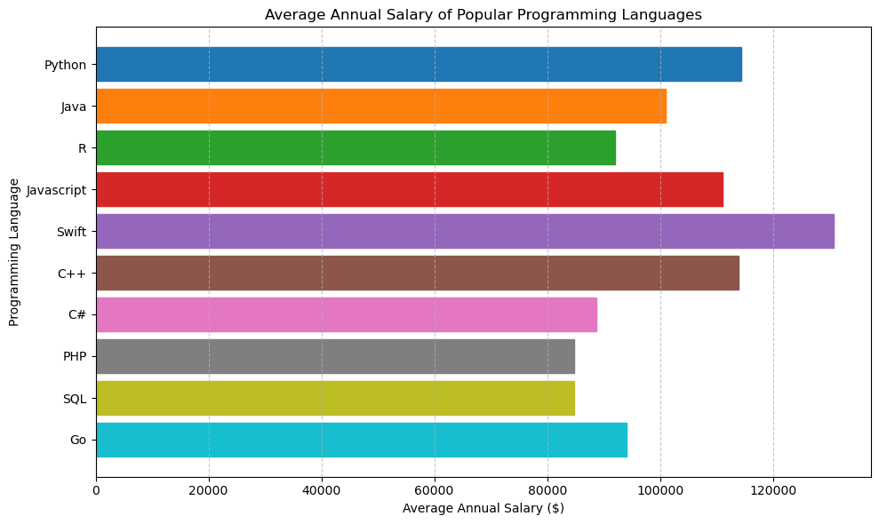

```python
# Generate a bar chart of Salaries
fig, ax = plt.subplots(figsize=(10, 6))
bars = ax.barh(df_languages["Language"], df_languages["Average Annual Salary"])

# Apply colorful bars
for i, bar in enumerate(bars):
    bar.set_color(plt.cm.tab10(i))

# Chart details
ax.set_title("Average Annual Salary of Popular Programming Languages")
ax.set_xlabel("Average Annual Salary ($)")
ax.set_ylabel("Programming Language")
ax.invert_yaxis()  # Highest salary at the top
plt.grid(axis='x', linestyle='--', alpha=0.7)
plt.tight_layout()
plt.show()
```

```python
# ALTERNATIVELY USE THIS

# Save as CSV
df_languages.to_csv('data/popular-languages.csv', index=False)

# Save as Excel
df_languages.to_excel('data/popular-languages.xlsx', index=False)
```